# Digital Signal Processing tutorial for EEG analysis

Digital signal processing is important in EEG analysis for several reasons:

- Noise reduction. EEG signals are often contaminated with various types of noise, including electrical interference, muscle artifacts, and environmental noise. Digital signal processing techniques such as filtering can effectively remove or reduce these unwanted components, improving the signal quality and making it easier to extract meaningful information from the EEG data.
- Feature extraction: EEG signals contain valuable information about brain activity and can be used to study various cognitive processes, neurological disorders, and mental states. Digital signal processing allows for the extraction of specific features from the EEG signals, such as power spectra, event-related potentials, or time-frequency representations. These features provide insights into the underlying brain dynamics and can be used for further analysis or classification purposes.

The purpose of this notebook is to give you some idea of how to apply basic signal processing techniques to your data.

```python
import mne
from mne.viz import plot_filter
import numpy as np
import scipy
import matplotlib.pyplot as plt
```

## Spectrum analysis and Power Spectrum Density (PSD) estimation

Different methods are employed in practice to estimate the spectrum, which includes alpha, beta, delta, and other bands of the EEG signal. While you may be familiar with Discrete Fourier Transform and Fast Fourier Transform from your studies, these techniques are not commonly used for spectrum estimation in practical applications.

Definition of Discrete Forier Transform

$$ X_k = \sum_{n=0}^{N-1} x_n \cdot e^{-i2\pi kn/N} $$

Definition of Power Spectrum Density

$$ S[k] = \frac{{|X[k]|^2}}{{N}} $$

```python
sfreq = 128
sig_freq_1 = 5
sig_freq_2 = 10
t_total = 10
t = np.linspace(0, t_total, t_total * sfreq)
n = len(t)
y = np.where(t < 5, np.sin(2 * np.pi * sig_freq_1 * t), np.sin(2 * np.pi * sig_freq_2 * t))
```

```python
sfreq_2 = 100
t_2 = np.linspace(0, t_total, t_total * sfreq_2)
n_2 = len(t_2)
y_2 = np.where(t_2 < 5, np.sin(2 * np.pi * sig_freq_1 * t_2), np.sin(2 * np.pi * sig_freq_2 * t_2))
```

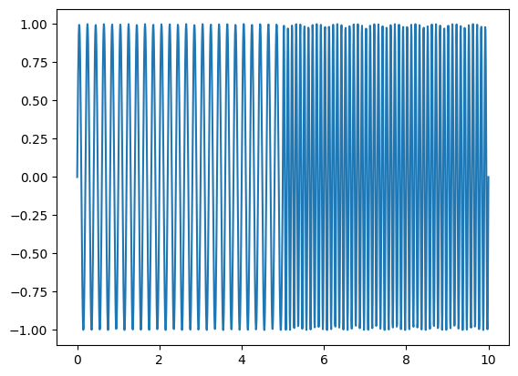

```python
plt.plot(t, y)
```

### Pure FFT approach

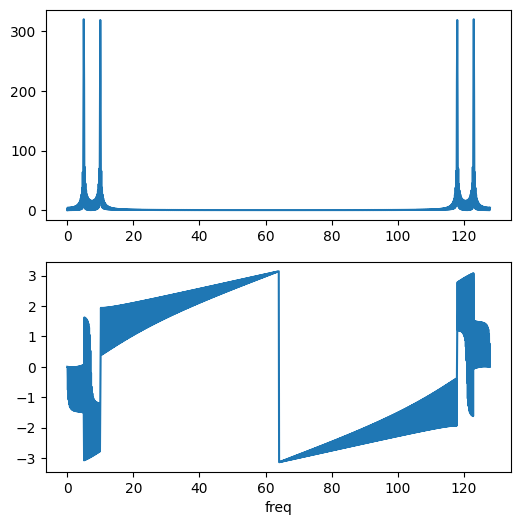

```python
w = np.fft.fft(y)
freqs = sfreq * np.arange(n) / n

fig, ax = plt.subplots(2, 1, figsize=(6, 6))
ax[0].plot(freqs, np.abs(w))
ax[1].plot(freqs, np.angle(w))
ax[1].set_xlabel('freq')
```

### Using the window

```python
ham = scipy.signal.windows.hamming(n)
```

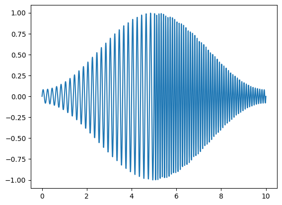

```python
plt.plot(t, y * ham)
```

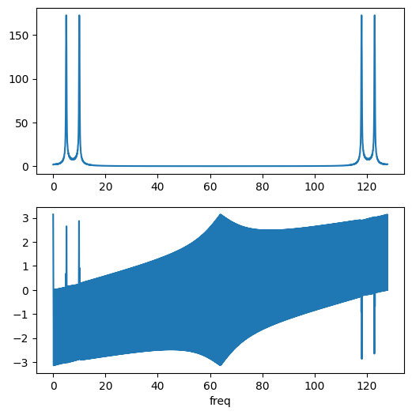

```python
w = np.fft.fft(y * ham)
freqs = sfreq * np.arange(n) / n

fig, ax = plt.subplots(2, 1, figsize=(6, 6))
ax[0].plot(freqs, np.abs(w))
ax[1].plot(freqs, np.angle(w))
ax[1].set_xlabel('freq')
```

### Welch method

The Welch method provides a more accurate and robust spectrum estimation technique compared to using only the FFT, making it a preferred choice in practical applications.

- Generates small sliding windows of the same shape (maybe with overlapping)
- Averages FFT^2

```
Effective window size : 2.000 (s)
```

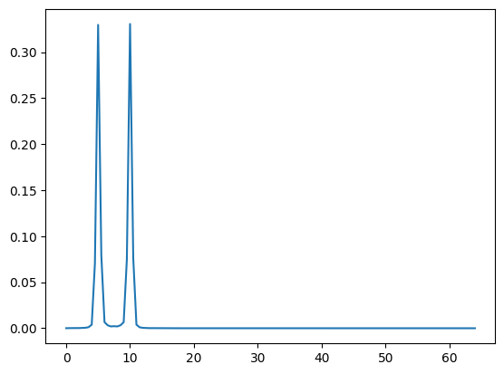

```python
pxx, freqs = mne.time_frequency.psd_array_welch(y, sfreq, n_fft=256)
plt.plot(freqs, pxx)
```

```
Effective window size : 0.500 (s)
```

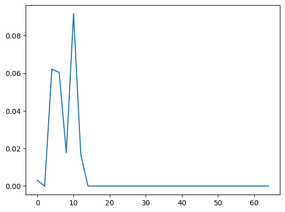

```python
pxx, freqs = mne.time_frequency.psd_array_welch(y, sfreq, n_fft=64)
plt.plot(freqs, pxx)
```

```
Effective window size : 0.250 (s)
```

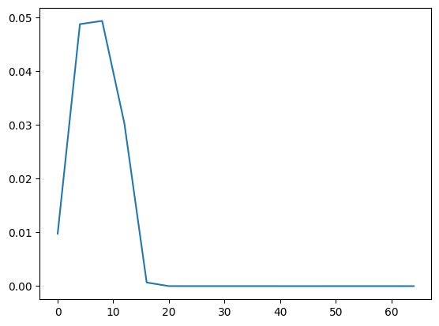

```python
pxx, freqs = mne.time_frequency.psd_array_welch(y, sfreq, n_fft=32)
plt.plot(freqs, pxx)
```

### Multitaper method

- Generates a family of windows, all-signal width, different shape
- Averages FFT^2

```
    Using multitaper spectrum estimation with 7 DPSS windows
```

[figure not shown]

```python
pxx, freqs = mne.time_frequency.psd_array_multitaper(y, sfreq)
plt.plot(freqs, pxx)
```

### Sampling frequency != 2^N

Welch method requires a specific number of points to function. Even if your sample contains a different number of points, the algorithm will adjust it to meet the required format. It can lead to some problems

```
Effective window size : 2.000 (s)
```

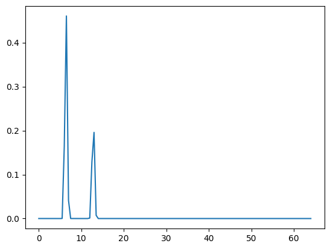

```python
pxx, freqs = mne.time_frequency.psd_array_welch(y_2, sfreq, n_fft=256)
plt.plot(freqs, pxx)
```

Multitaper performs better with the small samples

```
    Using multitaper spectrum estimation with 7 DPSS windows
```

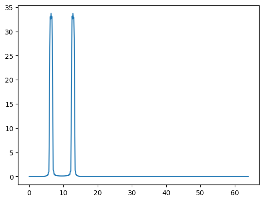

```python
pxx, freqs = mne.time_frequency.psd_array_multitaper(y_2, sfreq)
plt.plot(freqs, pxx)
```

More details

https://raphaelvallat.com/bandpower.html

## Digital filtering guide

A digital filter is a system that processes a discrete-time signal to modify its characteristics. It is typically used to remove or attenuate unwanted frequencies, enhance desired frequencies, or shape the frequency response of the signal.

There are two main types of digital filters: finite impulse response (FIR) filters and infinite impulse response (IIR) filters.

A comprehensive guide on digital filtering in EEG can be found [in this MNE guide](https://mne.tools/stable/auto_tutorials/preprocessing/25_background_filtering.html)

```python
sfreq = 128
sig_freq_1 = 0.5
sig_freq_2 = 8
sig_freq_3 = 50
bias = 1
t_total = 10
t = np.linspace(0, t_total, t_total * sfreq)
n = len(t)

y = bias + np.sin(2 * np.pi * sig_freq_1 * t) + np.sin(2 * np.pi * sig_freq_2 * t) + np.sin(2 * np.pi * sig_freq_3 * t)
```

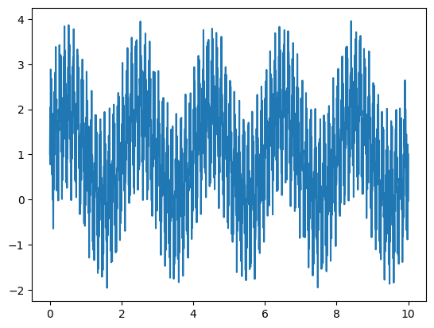

```python
plt.plot(t, y)
```

```
    Using multitaper spectrum estimation with 7 DPSS windows
```

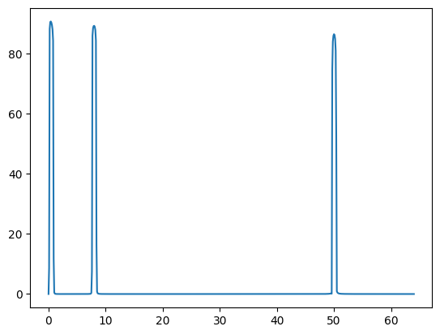

```python
pxx, freqs = mne.time_frequency.psd_array_multitaper(y, sfreq)
plt.plot(freqs, pxx)
```

```python
freq = [0.0, 1, 40, 64]
gain = [0.0, 1.0, 1.0, 0.0]
h = scipy.signal.firwin2(int(0.5 * sfreq), freq, gain, fs=sfreq)
h.shape
```

```
(64,)
```

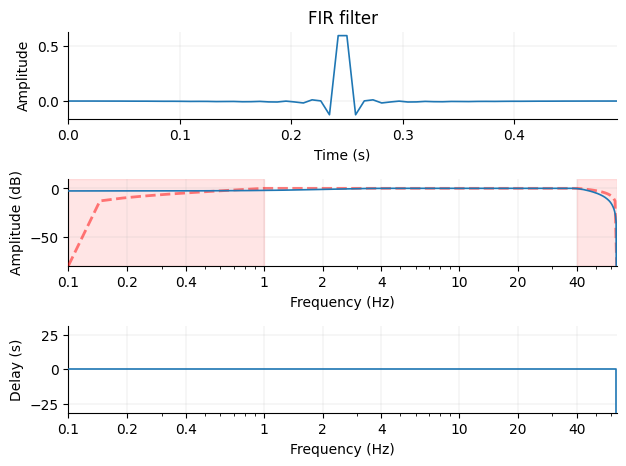

```python
plot_filter(h, sfreq, freq, gain);
```

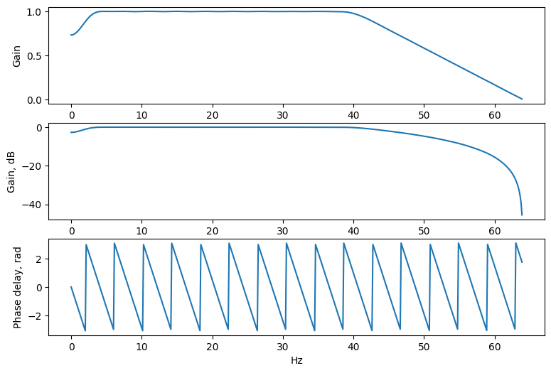

```python
phase_resp = scipy.signal.freqz(h)
fig, ax = plt.subplots(3, 1, figsize=(9, 6))

ax[0].plot(sfreq * phase_resp[0] / 2 / np.pi, np.abs(phase_resp[1]))
ax[1].plot(sfreq * phase_resp[0] / 2 / np.pi, 20 * np.log10(np.abs(phase_resp[1])))
ax[2].plot(sfreq * phase_resp[0] / 2 / np.pi, np.angle(phase_resp[1]))

ax[0].set_ylabel('Gain')
ax[1].set_ylabel('Gain, dB')
ax[2].set_ylabel('Phase delay, rad')
ax[2].set_xlabel('Hz')
```

```python
freq = [0.0, 1, 40, 64]
gain = [0.0, 1.0, 1.0, 0.0]
h = scipy.signal.firwin2(int(0.1 * sfreq), freq, gain, fs=sfreq)
h.shape
```

[output not shown]

```python
filt = scipy.signal.iirfilter(8, [1 / 64, 40 / 64], btype="band", ftype="butter", output="ba")
filt_sos = scipy.signal.iirfilter(8, [1 / 64, 40 / 64], btype="band", ftype="butter", output="sos")
```

```python
filt
```

```
(array([ 0.03229232,  0.        , -0.25833859,  0.        ,  0.90418505,
         0.        , -1.80837011,  0.        ,  2.26046264,  0.        ,
        -1.80837011,  0.        ,  0.90418505,  0.        , -0.25833859,
         0.        ,  0.03229232]),
 array([ 1.00000000e+00, -5.81649361e+00,  1.38910329e+01, -1.81350266e+01,
         1.64289714e+01, -1.47667545e+01,  1.29073275e+01, -7.47832974e+00,
         2.82830104e+00, -1.67067815e+00,  9.65441210e-01, -7.94439791e-02,
        -3.71645458e-02, -4.93724650e-02,  5.16890827e-03,  5.97403660e-03,
         1.04661464e-03]))
```

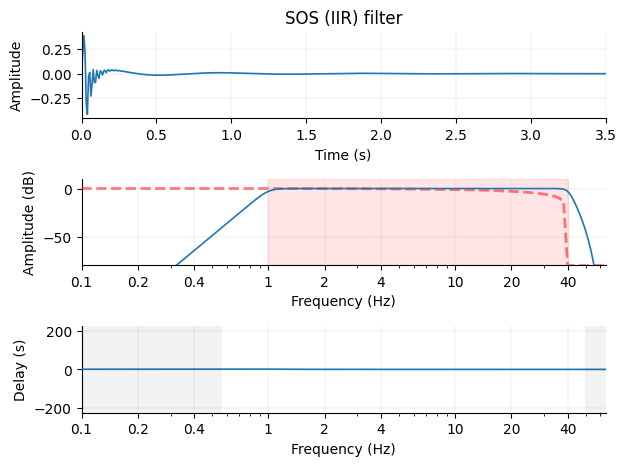

```python
plot_filter({'sos': filt_sos}, sfreq, freq, gain);
```

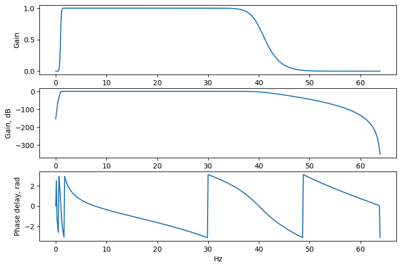

```python
phase_resp = scipy.signal.freqz(filt[0], filt[1])
fig, ax = plt.subplots(3, 1, figsize=(9, 6))

ax[0].plot(sfreq * phase_resp[0] / 2 / np.pi, np.abs(phase_resp[1]))
ax[1].plot(sfreq * phase_resp[0] / 2 / np.pi, 20 * np.log10(np.abs(phase_resp[1])))
ax[2].plot(sfreq * phase_resp[0] / 2 / np.pi, np.angle(phase_resp[1]))

ax[0].set_ylabel('Gain')
ax[1].set_ylabel('Gain, dB')
ax[2].set_ylabel('Phase delay, rad')
ax[2].set_xlabel('Hz')
```

### The rule of thumb

If you don't have specific knowledge of what you need to achieve with a filter, it is recommended to use the default FIR filter provided by MNE if you have long samples (e.g. loss up to 1s is ok) and use default IIR filter provided by MNE if you have short samples

IIR filters are more effective but have non-linear phase response which may affect on some EEG feature calculation (for example connectivity)

## Downsampling and anti-aliasing

The last but not list is applying downsampling to your data. Some EEG devices capture signals at sampling frequencies of 256 or even 512 Hz. It may be useful for some limited applications but is excessive for most common tasks.

A straight-forward (and wrong) approach to downsample data is to keep each Nth point

```python
sfreq = 128
sig_freq_1 = 8
sig_freq_2 = 50
t_total = 10
t = np.linspace(0, t_total, t_total * sfreq)
n = len(t)

y = np.sin(2 * np.pi * sig_freq_1 * t) + np.sin(2 * np.pi * sig_freq_2 * t)
```

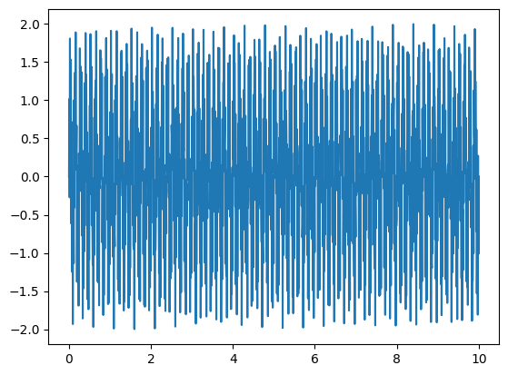

```python
plt.plot(t, y)
```

```
    Using multitaper spectrum estimation with 7 DPSS windows
```

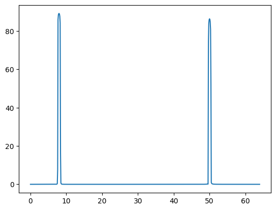

```python
pxx, freqs = mne.time_frequency.psd_array_multitaper(y, sfreq)
plt.plot(freqs, pxx)
```

```python
y_downsampled = y[::4]
```

```
    Using multitaper spectrum estimation with 7 DPSS windows
```

[figure not shown]

```python
pxx, freqs = mne.time_frequency.psd_array_multitaper(y_downsampled, sfreq / 2)
plt.plot(freqs, pxx)
```

What we see here is an **alias**. According to the [Nyquist-Shannon therem](https://en.wikipedia.org/wiki/Nyquist%E2%80%93Shannon_sampling_theorem) (also known as Kotelnikov theorem in Russian literature)

- If a function $x ( t )$ contains no frequencies higher than B hertz, then it can be completely determined from its ordinates at a sequence of points spaced less than $1 / ( 2 B )$ seconds apart.

Hence, in order to downsample, it is necessary to eliminate frequencies above half of the new sampling frequency. This can be achieved by employing a low-pass filter known as the **anti-aliasing filter**.

It is worth noting that aliasing can occur during signal capture, but EEG devices are equipped with built-in anti-aliasing filters to mitigate this issue.

Apply low-pass filter and verify the Nyquist-Shannon theorem

```python
## Your code here
```

Your can also use `np.signal.decimate`. MNE has `decimate` for epoched data and `resample` for raw data. But be aware of`resample` because it involves more complex computation